# Basic Research Methods: eye tracking tutorial

MagdaLena Matyjek

10/01/2020

# Materials

Slides from the lecture and from this tutorial can be found at:

https://github.com/lenamatyjek/ET_class

(click on “Clone or download” and download ZIP)

To sign-up for the participants’database, go to: https://www2.hu-berlin.de/ef-dg/mbexperiments You will be notified when there’s an ongoing study for which you are eligible.

# Hands-on exercise

Task:

- a passive-viewing task
- Three conditions: **positive**, **negative** and **neutral** pictures from IAPS (International Affective Picture System)

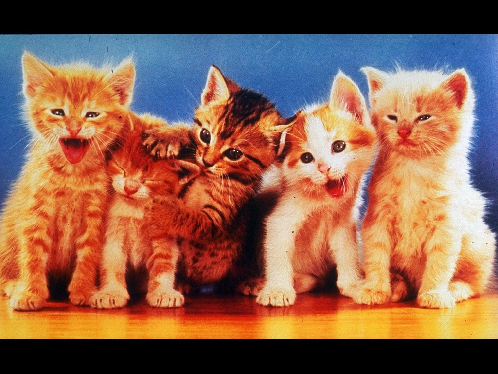

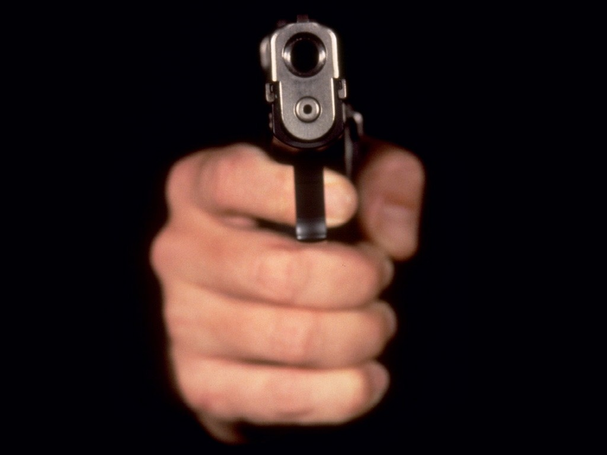

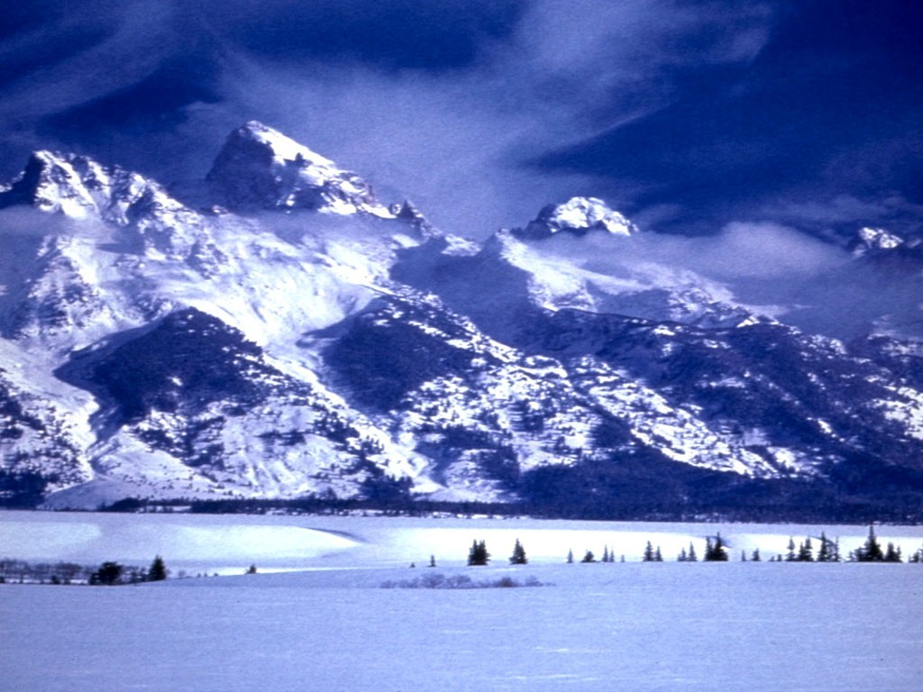

- 3000 ms presentation, 500 ms ITI
- 15 x each condition (no repeating items)
- time: ~3 min

# Procedure

1. Positioning
2. Calibration (+ re-calibration)
3. Data collection
4. Data pre-processing
5. Data visualisation
6. Data interpretation

# Hands-on time!

Now we collect data from volunteers. Meanwhile, form groups of 5-10 people and prepare the experimental design and predictions by considering the following points:

1.**Experimental design**:

- conditions (3: pos, neg, neu)
- no of repetitions of stimuli
- sample size + statistical power
- type of statistical analysis

2.**Research questions / hypotheses**

- backward reasoning: what could be the research question asked in this study?
- hypotheses and predictions: based on what you already know about eye tracking, pupillometry, and processing of emotional and neutral images in humans, propose your hypotheses and predictions for our results.

# Raw data

```r
# show the first 4 rows
head(rd,4)
```

```
##                 timestamp                   time        fix
## 1                     MSG 2020-01-07 10:17:43.26 1061923555
## 2 2020-01-07 10:17:43.023             1061923567       True
## 3 2020-01-07 10:17:43.040             1061923584       True
## 4 2020-01-07 10:17:43.056             1061923600       True
##             state     rawx     rawy     avgx     avgy    psize    Lrawx
## 1 start_recording       NA       NA       NA       NA       NA       NA
## 2               7 1063.299 719.7043 1036.940 699.1066 26.24940 1042.934
## 3               7 1040.149 710.0520 1037.394 698.9050 25.74415 1053.410
## 4               7 1051.085 682.4178 1038.015 699.0016 25.95300 1049.876
##      Lrawy    Lavgx    Lavgy  Lpsize Lpupilx Lpupily    Rrawx    Rrawy
## 1       NA       NA       NA      NA      NA      NA       NA       NA
## 2 757.5413 1050.300 710.9240 24.6516  0.3618  0.5723 1083.665 681.8673
## 3 739.2700 1050.397 712.3792 24.8139  0.3617  0.5719 1026.888 680.8340
## 4 715.2422 1050.301 712.5284 24.4666  0.3614  0.5715 1052.295 649.5936
##      Ravgx    Ravgy  Rpsize Rpupilx Rpupily
## 1       NA       NA      NA      NA      NA
## 2 1034.760 682.9311 27.8472  0.5856  0.5819
## 3 1034.889 682.8972 26.6744  0.5849  0.5815
## 4 1036.359 681.1251 27.4394  0.5849  0.5806
```

# Structured raw data

```r
  # show selected columns
  data <- rd[,c(1,3:5,13,20)]
  # ...and the first 5 rows
  head(data,5)
```

```
##                 timestamp             fix     rawx     rawy  Lpsize
## 1 2020-01-07 10:17:43.259 start_recording       NA       NA      NA
## 2 2020-01-07 10:17:43.023            True 1063.299 719.7043 24.6516
## 3 2020-01-07 10:17:43.039            True 1040.149 710.0520 24.8139
## 4 2020-01-07 10:17:43.055            True 1051.085 682.4178 24.4666
## 5 2020-01-07 10:17:43.072            True 1130.159 803.0325 24.5299
##    Rpsize
## 1      NA
## 2 27.8472
## 3 26.6744
## 4 27.4394
## 5 31.6633
```

# Pre-processing

- Pupil sizes were recorded binocularly using a desktop-mounted eye tracker (Eye Tribe, TheEyeTribe) at a 60 Hz sampling rate.
- Prior to the task, the eye tracker was calibrated with a nine-point grid.
- Offline preprocessing of the pupillary data was performed with Matlab code proposed by Kret & Sjak-Shie (2018). This includes:
- - blink and missing data interpolation
- - filtering
- - smoothing
- Segmentation and baseline correction were performed subsequently in R. Each segment was baseline-corrected (subtractive baseling correction: 200 ms).

# Pre-processed data

```
##    code  t_ms   sample cond trial_no segmentName size_fdb  t_fdb item
## 1  5555 2.729 23.12926  NEG        1    baseline -0.18744 -0.200  F10
## 2  5555 2.730 23.13093  NEG        1    baseline -0.18577 -0.199  F10
## 3  5555 2.731 23.13258  NEG        1    baseline -0.18412 -0.198  F10
## 4  5555 2.732 23.13421  NEG        1    baseline -0.18249 -0.197  F10
## 5  5555 2.733 23.13582  NEG        1    baseline -0.18088 -0.196  F10
## 6  5555 2.734 23.13741  NEG        1    baseline -0.17929 -0.195  F10
## 7  5555 2.735 23.13899  NEG        1    baseline -0.17771 -0.194  F10
## 8  5555 2.736 23.14055  NEG        1    baseline -0.17615 -0.193  F10
## 9  5555 2.737 23.14210  NEG        1    baseline -0.17460 -0.192  F10
## 10 5555 2.738 23.14363  NEG        1    baseline -0.17307 -0.191  F10
## 11 5555 2.739 23.14514  NEG        1    baseline -0.17156 -0.190  F10
## 12 5555 2.740 23.14664  NEG        1    baseline -0.17006 -0.189  F10
## 13 5555 2.741 23.14813  NEG        1    baseline -0.16857 -0.188  F10
## 14 5555 2.742 23.14960  NEG        1    baseline -0.16710 -0.187  F10
## 15 5555 2.743 23.15106  NEG        1    baseline -0.16564 -0.186  F10
## 16 5555 2.744 23.15252  NEG        1    baseline -0.16418 -0.185  F10
## 17 5555 2.745 23.15395  NEG        1    baseline -0.16275 -0.184  F10
## 18 5555 2.746 23.15538  NEG        1    baseline -0.16132 -0.183  F10
## 19 5555 2.747 23.15680  NEG        1    baseline -0.15990 -0.182  F10
## 20 5555 2.748 23.15821  NEG        1    baseline -0.15849 -0.181  F10
```

# Basic descriptives

Sample size:

```
## [1] 11
```

Mean, max, and min (relative to baseline):

```
## [1] 0.33
```

```
## [1] 17.64
```

```
## [1] -10.54
```

*Question*:

- What do negative values mean?

# Aggregate data

*Question*:

- What is data aggregation?

For plotting, we need the time course, but for statistics we have to aggregate the data over conditions and a time window. Here we will use 1 - 3 secs.

*Question*:

- Why won’t we use the data < 1 sec?

Aggregated data for plotting:

```
##   cond    t      size
## 1  CTR -0.2 0.2387024
## 2  NEG -0.2 0.3060968
## 3  POS -0.2 0.3476190
## 4  CTR -0.2 0.1403075
## 5  NEG -0.2 0.2111550
## 6  POS -0.2 0.1068884
```

Aggregated data for stats:

```
##   code cond        size
## 1 5555  CTR  1.05266400
## 2 6666  CTR  0.05027461
## 3 7777  CTR  0.60697429
## 4 8888  CTR  0.90672145
## 5 9999  CTR  0.61154801
## 6 3127  CTR -0.30504363
```

*Note*, that we display data here in the **long format**. For analyses in R, long format is required. However, different software may take the **wide format**, which in out case looks like this:

```
##   code         CTR         NEG        POS
## 1 5555  1.05266400  0.94421813  0.9563029
## 2 6666  0.05027461 -0.16892067 -0.2904782
## 3 7777  0.60697429  1.26059118  0.9487560
## 4 8888  0.90672145  1.15088713  0.5219658
## 5 9999  0.61154801  1.22619501  0.6229251
## 6 3127 -0.30504363  0.03609496  0.2438340
```

# Plotting the data - visual inspection

Let’s plot the averaged data over participants for each condition (the grey bands are the 95% confidence intervals):

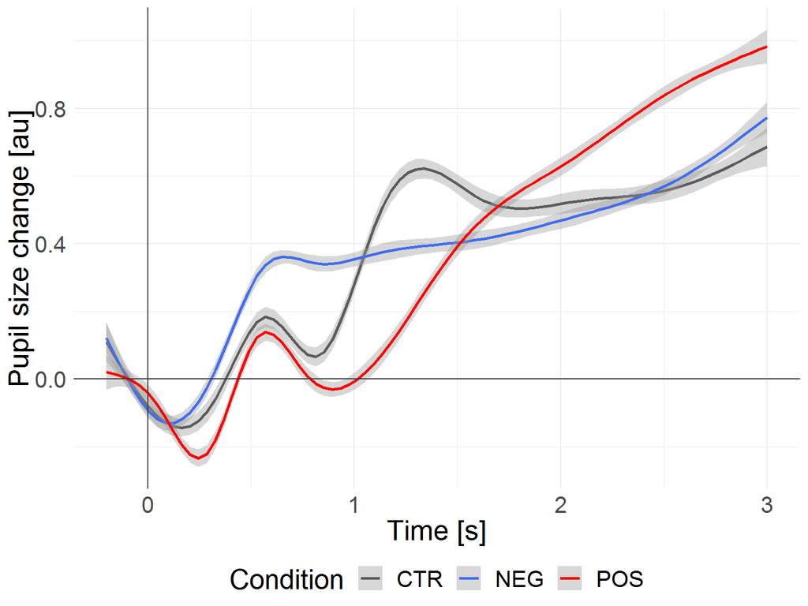

*Question*:

- What can we say about the results already?

# Individual plots

Do all participants respond with a similar pattern?

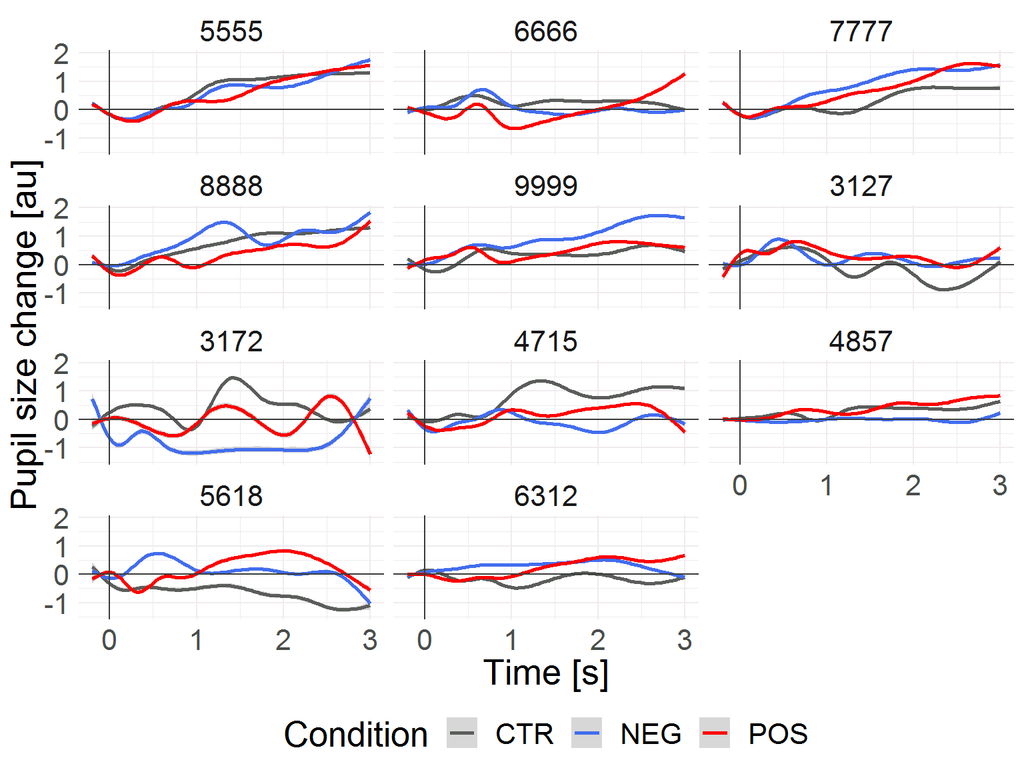

# Plotting the data - visual inspection 2

Let’s look at boxplots to have an idea about the spread of the data:

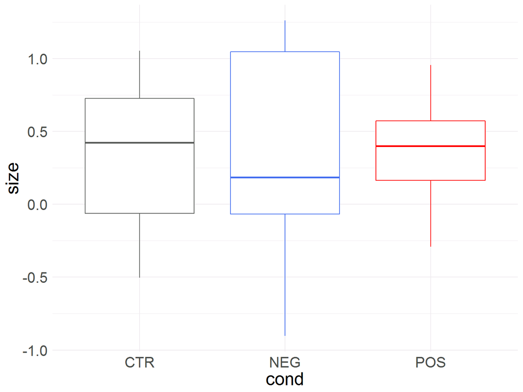

*Question*:

- What can we read in this plot?

# Luminance

We haven’t yet consider a very important aspect - the Pupil Light Reflex (PLR).

*Question*:

- How does PLR apply to out study? Is it a problem? How to deal with it?

Luminance - measurement of luminous intensity per unit area. Here - an approximation for human perception.

```
##    item code cond        size luminance
## 1    F1 5555  NEG  0.92652626       404
## 2    F1 6666  NEG -0.23834211       404
## 3    F1 7777  NEG  0.03855354       404
## 4    F1 8888  NEG  0.25898672       404
## 5    F1 9999  NEG  1.10894001       404
## 6    F1 3127  NEG  1.62180478       404
## 7    F1 3172  NEG  0.78394169       404
## 8    F1 4715  NEG -0.07128348       404
## 9    F1 4857  NEG  0.52517945       404
## 10   F1 5618  NEG -0.65155614       404
```

# Hypotheses testing

**H0.** There is no difference between the means of pupillary responses to the three conditions (POS = NEG = CTR)  
or: the means of the different groups are the same

**H1.** Mean responses to at least one condition are statistically significantly different than to one of the others.  
or: at least one sample mean is not equal to the others

Statistical test: repeated measures Analysic of Variance (rmANOVA) on a linear mixed model (LMM):

```r
library("lmerTest")

model_no_luminance = lmerTest::lmer(size ~ cond + (1|code), data=data_av_noLum, REML = F)
model = lmerTest::lmer(size ~ cond + luminance + (1|code), data=data_av, REML = F)
```

See the anova results for the model with luminance:

```r
anova(model)
```

```
## Type III Analysis of Variance Table with Satterthwaite's method
##            Sum Sq Mean Sq NumDF DenDF F value    Pr(>F)
## cond       4.5955  2.2977     2   484   0.965 0.3817106
## luminance 30.7633 30.7633     1   484  12.920 0.0003584 ***
## ---
## Signif. codes:  0 '***' 0.001 '**' 0.01 '*' 0.05 '.' 0.1 ' ' 1
```

*Question*:

- How can we read the results?

*Question*:

- Have we rejected the null hypothesis?

*Question*:

- If so, which groups differ in a statistically significant way?

**Which model is better - with or without luminance?**  
Q. 1: Does luminance explain a significant amount of variation?

```r
model.null = nlme::gls(size ~ 1, data_av, method = "ML")
model.lum = nlme::gls(size ~ luminance, data_av, method = 'ML')
anova(model.null,model.lum)
```

```
##            Model df      AIC      BIC    logLik   Test  L.Ratio p-value
## model.null     1  2 1881.999 1890.409 -938.9997
## model.lum      2  3 1873.823 1886.436 -933.9113 1 vs 2 10.17669  0.0014
```

Q.2: Does adding lumination as a covariate to the model improve the model or should there be a penalty for too many variables?

```r
AIC(model_no_luminance)
```

```
## [1] 50.03159
```

```r
AIC(model)
```

```
## [1] 1861.401
```

# Contrasts

Contrasts are linear combinations of variables, which allows their comparison. Let’s see how the contrasts look in our dataset:

```
##     NEG POS
## CTR   0   0
## NEG   1   0
## POS   0   1
```

This means that the model will set its “baseline” to the CONTROL condition, and show us two pairwise comparisons:  
CTR - NEG  
CTR - POS

# Pairwise comparisons - regression results

Plot of the results:

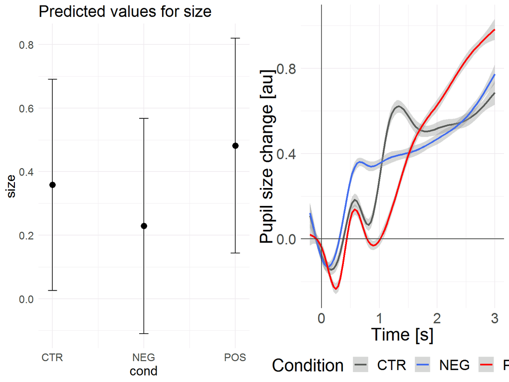

To see pairwise comparisons, we have to either perform post-hoc tests, or look into the results of the regression model:

```
## Linear mixed model fit by maximum likelihood . t-tests use
##   Satterthwaite's method [lmerModLmerTest]
## Formula: size ~ cond + luminance + (1 | code)
##    Data: data_av
##
##      AIC      BIC   logLik deviance df.resid
##   1861.4   1886.6   -924.7   1849.4      489
##
## Scaled residuals:
##     Min      1Q  Median      3Q     Max
## -5.9043 -0.4841  0.0352  0.6018  3.3188
##
## Random effects:
##  Groups   Name        Variance Std.Dev.
##  code     (Intercept) 0.1582   0.3977
##  Residual             2.3810   1.5431
## Number of obs: 495, groups:  code, 11
##
## Fixed effects:
##               Estimate Std. Error         df t value  Pr(>|t|)
## (Intercept)   1.038487   0.255382 112.378976   4.066 0.0000889 ***
## condNEG      -0.129538   0.173425 484.000002  -0.747  0.455463
## condPOS       0.123031   0.172497 484.000002   0.713  0.476046
## luminance    -0.001384   0.000385 484.000002  -3.594  0.000358 ***
## ---
## Signif. codes:  0 '***' 0.001 '**' 0.01 '*' 0.05 '.' 0.1 ' ' 1
##
## Correlation of Fixed Effects:
##           (Intr) cndNEG cndPOS
## condNEG   -0.476
## condPOS   -0.198  0.448
## luminance -0.747  0.201 -0.173
```

*Question*:

- **What is our main finding? Did we find an effect of condition? How do we interpret this (luminance, valence, arousal, cognitive load…)?**

*Question*:

- What are effect sizes and where are they in this output?

# Neglected (and very important) elements of the study

Our “study” misses a few critical points which should be carefully considered and addressed by researchers:

- First literature review, research questions and hypotheses! Then design, pilot and data collection.
- Assumptions for statistical tests (normality, linear relation, multicollinearity, homoscedasticity).
- Sample size based on power analysis (making sure we have anough power to show an effect).
- AOIs - did people actually look at the stimuli?
- Outliers - are there any and should we remove them?

# Summary

We conducted a short study investigating pupillary responses to emotionally loaded and neutral images.

**Research question:**

- Do pupillary responses to negative (scary, disgusting, sad), positive (happy, “cute”, sexually arousal), and neutral images differ? /// Do pos, neg and neu images differ in arousal? // …

**Hypothesis (for example):**

- Arousing images elicit larger pupil sizes as compared to neutral images (regardless of valence). <- a directed hypothesis.

**Design: sample size, inclusion / exclusion criteria, how were they recruited, how were they reimbursed?**

- …, students in the Basic Research Methods course with normal r corrected-to-normal vision, participation in the class, reimbursed with knowledge! :)

**Dependent variable:**

- pupil size

**Independent variable:**

- condition

**Confounding variables (covariates):**

- luminance of the images

**Statistical procedures:**

- Linear Regression Mixed Model and ANOVA (to estimate the main effect of condition).

# Questions and / or comments?

Thank you for your attention!

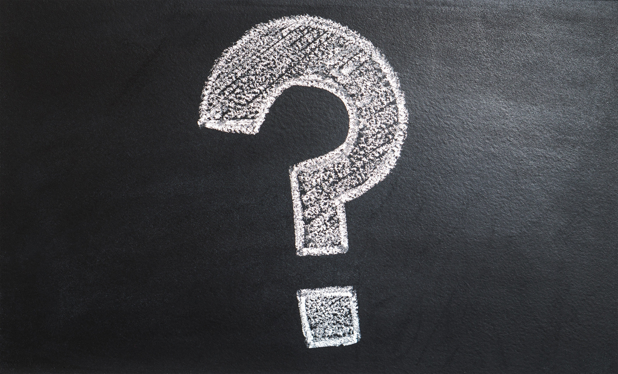